# Atividade: Modelos probabilísticos contínuos e Dados

## Aula 14

**Preparo Prévio:**

1. Leitura prévia necessária: Magalhães e Lima (7ª. Edição): Modelo Normal (pág. 197 a 201).
2. Executar o arquivo `Aula13 Modelos probabilísticos contínuos.ipynb`
3. Leitura prévia necessária: Magalhães e Lima (7ª. Edição): Gráfico de quantis ou QQplot (pág. 27 - Exemplo 1.10 e 1.11).
4. Leitura prévia necessária: Magalhães e Lima (7ª. Edição): Gráfico de probabilidade (similar ao gráfico QQplot) (pág. 201 a 204) - Exemplo 6.10).

**Hoje:**

1. Reforçar mais ferramentas para Análise Descritiva
2. Avaliar, descritivamente, adequação da normal aos dados.
3. Contrastar resultados teóricos e empíricos.

**Próxima aula:**

1. Leitura prévia necessária: Magalhães e Lima (7ª. Edição): Seção 5.1 (pág. 137) e Seção 5.2 (pág. 146).

## Padaria

Uma empresa deve decidir onde construir uma padaria: Bairro A ou Bairro B .

Como ambos os bairros possuem densidades populacionais próximas, os investidores visam atingir um público alvo de maior renda familiar. Assim, quanto maior o número de famílias com rendas familiares mais altas, maior será a chance do empreendimento ser bem sucedido.

Considerando que a decisão final seja baseada em informações sobre a renda familiar dos moradores desses dois bairros, responda:

1. Calcule algumas medidas resumo úteis para entender o comportamento dessa variável em ambos os bairros. Analise.
2. Construa o histograma dos dados e compare as distribuições de renda familiar (em mil reais) dos dois bairros. Qual é o melhor bairro para construir a padaria? Justifique.
3. Construa o QQ-Plot considerando quantil amostral do Bairro A vs quantil amostral do Bairro B. Esse gráfico de quantis amostrais auxilia a responder qual é o melhor bairro para construir a padaria? Justifique claramente. Dica: veja construção desse gráfico no Magalhães e Lima (7ª edição) - pág. 27 e 29.
4. Assuma que $X$: renda familiar de um determinado bairro tenha $\mu$ estimada pela média amostral ($\bar{x}$) e tenha $\sigma^2$ estimada pela variância amostral, ambas de um mesmo bairro em questão. Verifique, visualmente/graficamente, se a distribuição normal é adequada para estimar a renda familiar de cada bairro. Para isso, interprete os seguintes gráficos:
   1. Construa o histograma dos dados junto com a fdp da distribuição normal e analise.
   2. Construa o Gráfico de probabilidade considerando o quantil amostral vs o quantil teórico da distribuição normal. Interprete esse gráfico com intuito de avaliar se: A renda de cada bairro é bem modelada por uma distribuição normal? Dica: veja Exemplo 6.8 do Magalhães e Lima (7ª. edição) de como obter as frequências relativas acumuladas a partir de uma amostra de tamanho n=500 (de cada bairro). Os quantis teóricos da distribuição normal podem ser obtidos pelo comando `stats.norm.ppf(p, loc=mu, scale=sigma)`, sendo `p` a frequencia relativa acumulada obtida anteriormente.
   3. Construa um gráfico dos valores observados vs frequência relativa acumulada (a partir dos dados) e vs função de distribuição acumulada.
5. Independente da sua resposta do item anterior, assuma que $X$: renda familiar de um determinado bairro segue uma distribuição normal considerando as estimativas amostrais como valores dos parâmetros de cada bairro. Nesse caso, para cada bairro, calcule:
   1. probabilidade de uma família possuir renda familiar maior do que 17 mil reais.
   2. sabendo que a famíliar tem mais do que 15 mil reais de renda familiar, qual a probabilidade dessa possuir renda inferior a 16 mil reais.
   3. qual a menor renda familiar dos 5% das famílias que mais ganham em cada bairro?

```python
%matplotlib inline

import os
import matplotlib.pyplot as plt
import pandas as pd
from scipy import stats
from numpy import mean, var, arange

print('Esperamos trabalhar no diretório')
print(os.getcwd())
```

```
Esperamos trabalhar no diretório
/home/hugogr
```

```python
df = pd.read_excel('Padaria.xlsx')
```

```python
df.describe()
```

|  | A | B |
| --- | --- | --- |
| count | 500.000000 | 500.000000 |
| mean | 15.321676 | 14.221997 |
| std | 0.592599 | 1.840182 |
| min | 13.450880 | 9.704160 |
| 25% | 14.919380 | 12.843832 |
| 50% | 15.335840 | 14.348205 |
| 75% | 15.702140 | 15.770295 |
| max | 17.151280 | 18.911520 |

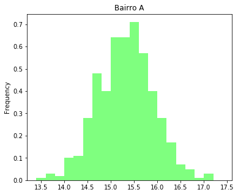

```python
faixa = arange(13.4,17.5,0.2)
plot = df['A'].plot.hist(bins=faixa, title='Bairro A', figsize=(6,5), normed = 1, alpha=0.5, color = 'lime')
```

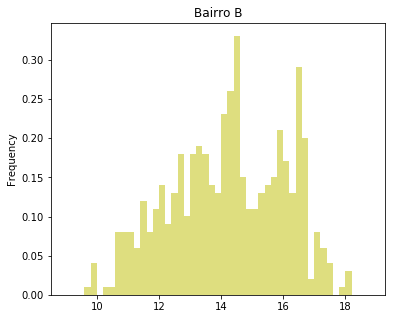

```python
faixa = arange(9,19,0.2)
plot = df['B'].plot.hist(bins=faixa, title='Bairro B', figsize=(6,5), normed = 1, alpha=0.5, color = 'y')
```

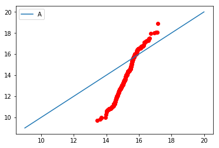

```python
xa = sorted(df.A)
xb = sorted(df.B)
plot = plt.scatter(xa,xb,color=['r'])
plt.plot((9,20),(9,20),'-')
plt.legend(['A'])
```

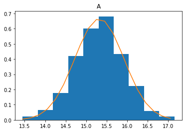

```python
ua = 15.32
sigma = 0.6
loc = ua
scale = sigma

#x = stats.norm.cdf(faixa,loc,scale)

plt.hist(df.A, normed = True)
xa = arange(df.A.min(), df.A.max(), 0.2)
plt.plot(xa, stats.norm.pdf(xa, loc, scale))
plt.title('A')
```

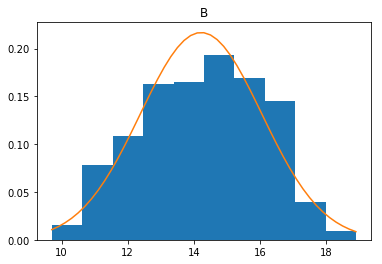

```python
ub = 14.22
sigmab = 1.84
locb = ub
scaleb = sigmab

plt.hist(df.B, normed = True)
xb = arange(df.B.min(), df.B.max(), 0.2)
plt.plot(xb, stats.norm.pdf(xb, locb, scaleb))
plt.title('B')
```

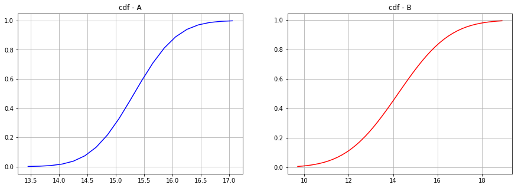

```python
fig = plt.figure(figsize=(15,5))
plt.subplot(121)
plt.plot(xa, stats.norm.cdf(xa,loc,scale), color = 'b')
plt.grid()
plt.title('cdf - A')

plt.subplot(122)
plt.plot(xb, stats.norm.cdf(xb,locb,scaleb),color='r')
plt.grid()
plt.title('cdf - B')
```